# Two-way ANCOVA: 9th Grade Academy, Attendance, and Race

## ANCOVA

This ANCOVA looks at the effect of attending a 9th grade academy, and the students race as Minority / White of Asian on 9th grade GPA while controlling for 8th grade attendance.

## Assumptions

### Linearity assumption

The covariate, 8th grade attendance, and the outcome variable should have a linear relationship for each group.

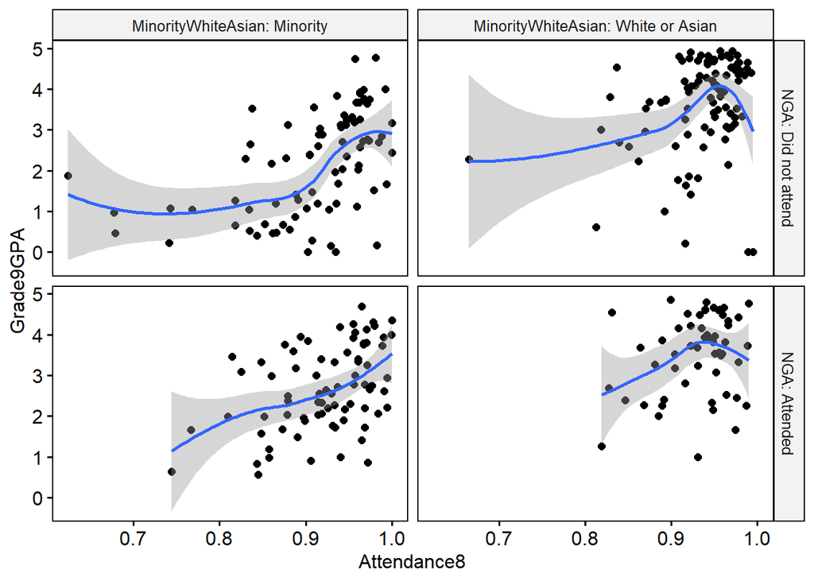

### Homogeneity of regression slopes

This assumption checks that there is no significant interaction between the covariate and the grouping variables.

| Effect | DFn | DFd | F | p | p<.05 | ges |
| --- | --- | --- | --- | --- | --- | --- |
| Attendance8 | 1 | 303 | 37.41 | 0.000 | * | 0.110 |
| NGA | 1 | 303 | 0.02 | 0.896 |  | 0.000 |
| MinorityWhiteAsian | 1 | 303 | 1.18 | 0.279 |  | 0.004 |
| NGA:MinorityWhiteAsian | 1 | 303 | 0.01 | 0.914 |  | 0.000 |
| Attendance8:NGA | 1 | 303 | 0.00 | 0.954 |  | 0.000 |
| Attendance8:MinorityWhiteAsian | 1 | 303 | 0.39 | 0.532 |  | 0.001 |
| Attendance8:NGA:MinorityWhiteAsian | 1 | 303 | 0.00 | 0.998 |  | 0.000 |

The table above shows there was homogeneity of the regression slopes. The interaction between the covariate (Grade 8 Attendance) and grouping variables (NGA and minority / White or Asian), was not statistically significant, p > 0.05.

#### Normality of residuals

| Grade9GPA | Attendance8 | NGA | MinorityWhiteAsian | .resid | .cooksd | .std.resid |
| --- | --- | --- | --- | --- | --- | --- |
| 4.00 | 0.9922 | Did not attend | Minority | 1.2002 | 0.0053181 | 1.1717 |
| 0.64 | 0.7442 | Attended | Minority | -0.6638 | 0.0040014 | -0.6566 |
| 1.41 | 0.8882 | Did not attend | Minority | -0.5911 | 0.0008454 | -0.5752 |

| variable | statistic | p.value |
| --- | --- | --- |
| model.metrics$.resid | 0.9653 | 8.945e-07 |

The Shapiro Wilk test was significant (p < 0.05), therefore the assumption of normality of residuals is violated. Visual inspection of the QQ plots in SPSS, not shown here, show the violation may be a result of higher than expected values at the top end of both 8th grade attendance and 9th grade GPA. A small porportion of students recieved the highest score, e.g. perfect attendance and GPA, causing the distrubtion to be skewed. Due to the larger sample size, and no other violations I think the Shaprio Wilks violation is not a large concern.

#### Homogeneity of variances

| df1 | df2 | statistic | p |
| --- | --- | --- | --- |
| 3 | 307 | 0.6904 | 0.5585 |

The Levene’s test was not significant (p > 0.05), so we can assume homogeneity of the residual variances for all groups.

#### Outliers

| Grade9GPA | Attendance8 | NGA | MinorityWhiteAsian | .resid | .cooksd | .std.resid |
| --- | --- | --- | --- | --- | --- | --- |
| 0 | 0.995 | Did not attend | White or Asian | -4.094 | 0.04517 | -3.986 |
| 0.21 | 0.916 | Did not attend | White or Asian | -3.277 | 0.02206 | -3.186 |
| 0 | 0.9892 | Did not attend | White or Asian | -4.049 | 0.04206 | -3.941 |

There are 3 outliers as shown above, out of the sample size of 311 this is not concerning.

### Computation

Anova Table (Type III tests)

|  | Sum Sq | Df | F value | Pr(>F) |
| --- | --- | --- | --- | --- |
| **(Intercept)** | 19.955 | 1 | 18.656 | 0.000 |
| **Attendance8** | 60.098 | 1 | 56.186 | 0.000 |
| **NGA** | 2.127 | 1 | 1.988 | 0.160 |
| **MinorityWhiteAsian** | 78.196 | 1 | 73.106 | 0.000 |
| **NGA:MinorityWhiteAsian** | 4.234 | 1 | 3.959 | 0.048 |
| **Residuals** | 327.304 | 306 | NA | NA |

After adjustment for 8th grade attendance, there was a statistically significant difference in 9th grade GPA between the Minority students and White or Asain students who attended the 9th Grade Academy. Attendance of the 9th Grade Academy itself did not have a significant effect, but both 8th grade attendance and minority status did have an effect by themselves.

### Post-hoc test

The post-hoc test below, with a Bonferroni adjustment, show that there is a significant finding among minority students and their academy attendance.

| MinorityWhiteAsian | .y. | group1 | group2 | df | statistic | p | p.adj | p.adj.signif |
| --- | --- | --- | --- | --- | --- | --- | --- | --- |
| Minority | Grade9GPA | Did not attend | Attended | 306 | -2.484 | 0.01353 | 0.01353 | * |
| White or Asian | Grade9GPA | Did not attend | Attended | 306 | 0.4 | 0.6894 | 0.6894 | ns |

| Attendance8 | MinorityWhiteAsian | NGA | emmean | se | df | conf.low | conf.high | method |
| --- | --- | --- | --- | --- | --- | --- | --- | --- |
| 0.9243 | Minority | Did not attend | 2.278 | 0.1153 | 306 | 2.051 | 2.505 | Emmeans test |
| 0.9243 | Minority | Attended | 2.686 | 0.1171 | 306 | 2.455 | 2.916 | Emmeans test |
| 0.9243 | White or Asian | Did not attend | 3.55 | 0.1061 | 306 | 3.342 | 3.759 | Emmeans test |
| 0.9243 | White or Asian | Attended | 3.48 | 0.1396 | 306 | 3.206 | 3.755 | Emmeans test |

Minority students who attended the 9th Grade Academy have an estimated 9th grade GPA .408 higher than students who did not attend. The difference in GPA for White or Asian students based on attendance was small, and not significant.

## Report

A two-way ANCOVA was performed to examine the effects of attending a 9th Grade Academy and race on 9th grade GPA, after controlling for 8th grade attendance.

There was a statistically significant two-way interaction between race and academy attendance on score 9th grade GPA, while controlling for 8th grade attendance, F(1, 306) = 3.959, p = 0.048.

Post-hoc analysis was preformed using a Bonferroni adjusment showing significant results for minority students (p = .014). but not for White or Asian students (p = .689).

The pairwise compasion of estimated marginal means show that minority students who attended the academy have a .408 higher predicted GPA than those who did not attend. These results are presented in the graph below.

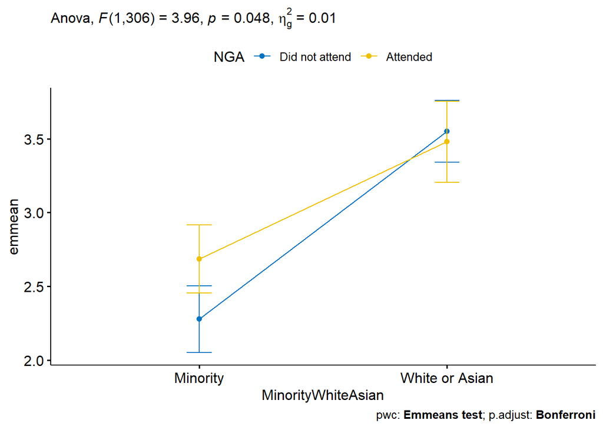